# main

```python
import numpy as np
import pandas as pd
import tensorflow as tf
import keras
from sklearn.linear_model import LinearRegression
from sklearn.model_selection import train_test_split
from sklearn.ensemble import GradientBoostingRegressor
from sklearn.metrics import mean_absolute_error
from sklearn.model_selection import GridSearchCV
import seaborn as sns
import matplotlib
import matplotlib.pyplot as plt
sns.set()

import keras
from keras.models import Sequential
from keras.layers import Dense, Dropout
from keras.utils import to_categorical
from sklearn.preprocessing import StandardScaler
from sklearn.preprocessing import LabelEncoder
from sklearn.model_selection import train_test_split
from sklearn.decomposition import PCA
```

```python
INPUT_DIR= "./data/input"
OUTPUT_DIR= "./data/output"
```

```python
train_df = pd.read_csv(INPUT_DIR+r"/dengue_features_train.csv")
test_df = pd.read_csv(INPUT_DIR+r"/dengue_features_test.csv")
train_label = pd.read_csv(INPUT_DIR+r"/dengue_labels_train.csv")["total_cases"]
```

```python
print(train_label.describe())
print()
print(train_label.sample(5))
```

```
count    1456.000000
mean       24.675137
std        43.596000
min         0.000000
25%         5.000000
50%        12.000000
75%        28.000000
max       461.000000
Name: total_cases, dtype: float64

1218     7
582     22
851     23
1051    22
112     29
Name: total_cases, dtype: int64
```

```python
train_df.head(25)
```

|  | city | year | weekofyear | week_start_date | ndvi_ne | ndvi_nw | ndvi_se | ndvi_sw | precipitation_amt_mm | reanalysis_air_temp_k | ... | reanalysis_precip_amt_kg_per_m2 | reanalysis_relative_humidity_percent | reanalysis_sat_precip_amt_mm | reanalysis_specific_humidity_g_per_kg | reanalysis_tdtr_k | station_avg_temp_c | station_diur_temp_rng_c | station_max_temp_c | station_min_temp_c | station_precip_mm |
| --- | --- | --- | --- | --- | --- | --- | --- | --- | --- | --- | --- | --- | --- | --- | --- | --- | --- | --- | --- | --- | --- |
| 0 | sj | 1990 | 18 | 1990-04-30 | 0.122600 | 0.103725 | 0.198483 | 0.177617 | 12.42 | 297.572857 | ... | 32.00 | 73.365714 | 12.42 | 14.012857 | 2.628571 | 25.442857 | 6.900000 | 29.4 | 20.0 | 16.0 |
| 1 | sj | 1990 | 19 | 1990-05-07 | 0.169900 | 0.142175 | 0.162357 | 0.155486 | 22.82 | 298.211429 | ... | 17.94 | 77.368571 | 22.82 | 15.372857 | 2.371429 | 26.714286 | 6.371429 | 31.7 | 22.2 | 8.6 |
| 2 | sj | 1990 | 20 | 1990-05-14 | 0.032250 | 0.172967 | 0.157200 | 0.170843 | 34.54 | 298.781429 | ... | 26.10 | 82.052857 | 34.54 | 16.848571 | 2.300000 | 26.714286 | 6.485714 | 32.2 | 22.8 | 41.4 |
| 3 | sj | 1990 | 21 | 1990-05-21 | 0.128633 | 0.245067 | 0.227557 | 0.235886 | 15.36 | 298.987143 | ... | 13.90 | 80.337143 | 15.36 | 16.672857 | 2.428571 | 27.471429 | 6.771429 | 33.3 | 23.3 | 4.0 |
| 4 | sj | 1990 | 22 | 1990-05-28 | 0.196200 | 0.262200 | 0.251200 | 0.247340 | 7.52 | 299.518571 | ... | 12.20 | 80.460000 | 7.52 | 17.210000 | 3.014286 | 28.942857 | 9.371429 | 35.0 | 23.9 | 5.8 |
| 5 | sj | 1990 | 23 | 1990-06-04 | NaN | 0.174850 | 0.254314 | 0.181743 | 9.58 | 299.630000 | ... | 26.49 | 79.891429 | 9.58 | 17.212857 | 2.100000 | 28.114286 | 6.942857 | 34.4 | 23.9 | 39.1 |
| 6 | sj | 1990 | 24 | 1990-06-11 | 0.112900 | 0.092800 | 0.205071 | 0.210271 | 3.48 | 299.207143 | ... | 38.60 | 82.000000 | 3.48 | 17.234286 | 2.042857 | 27.414286 | 6.771429 | 32.2 | 23.3 | 29.7 |
| 7 | sj | 1990 | 25 | 1990-06-18 | 0.072500 | 0.072500 | 0.151471 | 0.133029 | 151.12 | 299.591429 | ... | 30.00 | 83.375714 | 151.12 | 17.977143 | 1.571429 | 28.371429 | 7.685714 | 33.9 | 22.8 | 21.1 |
| 8 | sj | 1990 | 26 | 1990-06-25 | 0.102450 | 0.146175 | 0.125571 | 0.123600 | 19.32 | 299.578571 | ... | 37.51 | 82.768571 | 19.32 | 17.790000 | 1.885714 | 28.328571 | 7.385714 | 33.9 | 22.8 | 21.1 |
| 9 | sj | 1990 | 27 | 1990-07-02 | NaN | 0.121550 | 0.160683 | 0.202567 | 14.41 | 300.154286 | ... | 28.40 | 81.281429 | 14.41 | 18.071429 | 2.014286 | 28.328571 | 6.514286 | 33.9 | 24.4 | 1.1 |
| 10 | sj | 1990 | 28 | 1990-07-09 | 0.192875 | 0.082350 | 0.191943 | 0.152929 | 22.27 | 299.512857 | ... | 43.72 | 81.467143 | 22.27 | 17.418571 | 2.157143 | 27.557143 | 7.157143 | 31.7 | 21.7 | 63.7 |
| 11 | sj | 1990 | 29 | 1990-07-16 | 0.291600 | 0.211800 | 0.301200 | 0.280667 | 59.17 | 299.667143 | ... | 40.90 | 82.144286 | 59.17 | 17.737143 | 2.414286 | 28.128571 | 6.900000 | 32.8 | 23.9 | 12.2 |
| 12 | sj | 1990 | 30 | 1990-07-23 | 0.150567 | 0.171700 | 0.226900 | 0.214557 | 16.48 | 299.558571 | ... | 42.53 | 80.742857 | 16.48 | 17.341429 | 2.071429 | 28.114286 | 6.357143 | 31.7 | 22.8 | 32.6 |
| 13 | sj | 1990 | 31 | 1990-07-30 | NaN | 0.247150 | 0.379700 | 0.381357 | 32.66 | 299.862857 | ... | 34.60 | 80.584286 | 32.66 | 17.594286 | 2.585714 | 28.242857 | 8.085714 | 34.4 | 22.8 | 37.6 |
| 14 | sj | 1990 | 32 | 1990-08-06 | NaN | 0.064333 | 0.164443 | 0.138857 | 28.80 | 300.391429 | ... | 20.00 | 79.650000 | 28.80 | 17.950000 | 2.328571 | 28.200000 | 7.557143 | 33.3 | 23.3 | 11.4 |
| 15 | sj | 1990 | 33 | 1990-08-13 | NaN | 0.128033 | 0.206957 | 0.168243 | 90.75 | 299.958571 | ... | 101.90 | 84.178571 | 90.75 | 18.515714 | 1.857143 | 28.042857 | 6.685714 | 32.8 | 22.8 | 44.7 |
| 16 | sj | 1990 | 34 | 1990-08-20 | 0.190233 | 0.168800 | 0.167657 | 0.172286 | 32.40 | 300.332857 | ... | 25.90 | 80.947143 | 32.40 | 18.174286 | 2.485714 | 28.342857 | 7.014286 | 33.3 | 23.3 | 5.4 |
| 17 | sj | 1990 | 35 | 1990-08-27 | 0.252900 | 0.330750 | 0.264171 | 0.284314 | 40.94 | 300.118571 | ... | 39.80 | 83.348571 | 40.94 | 18.515714 | 1.900000 | 28.657143 | 6.528571 | 32.2 | 24.4 | 13.7 |
| 18 | sj | 1990 | 36 | 1990-09-03 | 0.235400 | 0.200025 | 0.283817 | 0.230443 | 28.86 | 300.530000 | ... | 30.40 | 77.172857 | 28.86 | 17.560000 | 3.471429 | 28.328571 | 7.614286 | 32.8 | 23.3 | 14.2 |
| 19 | sj | 1990 | 37 | 1990-09-10 | 0.127967 | 0.437100 | 0.123400 | 0.148283 | 64.56 | 300.674286 | ... | 24.18 | 81.551429 | 64.56 | 18.777143 | 2.900000 | 28.685714 | 8.057143 | 33.9 | 24.4 | 25.9 |
| 20 | sj | 1990 | 38 | 1990-09-17 | 0.196350 | 0.182433 | 0.254829 | 0.305686 | 143.73 | 299.857143 | ... | 36.60 | 81.637143 | 143.73 | 17.892857 | 1.742857 | 28.242857 | 8.114286 | 32.8 | 23.9 | 3.3 |
| 21 | sj | 1990 | 39 | 1990-09-24 | 0.116100 | 0.260900 | 0.199443 | 0.244217 | 51.39 | 300.427143 | ... | 16.40 | 77.048571 | 51.39 | 17.468571 | 2.257143 | 28.342857 | 7.728571 | 32.8 | 24.4 | 15.8 |
| 22 | sj | 1990 | 40 | 1990-10-01 | 0.228550 | 0.189750 | 0.212486 | 0.201186 | 31.18 | 300.775714 | ... | 36.10 | 78.520000 | 31.18 | 18.180000 | 2.900000 | 28.771429 | 8.028571 | 33.3 | 23.9 | 11.7 |
| 23 | sj | 1990 | 41 | 1990-10-08 | 0.171150 | 0.067550 | 0.179467 | 0.157717 | 51.42 | 299.857143 | ... | 132.40 | 84.110000 | 51.42 | 18.512857 | 2.571429 | 28.628571 | 7.314286 | 33.3 | 24.4 | 57.7 |
| 24 | sj | 1990 | 42 | 1990-10-15 | NaN | 0.070200 | 0.181617 | 0.165750 | 143.55 | 299.195714 | ... | 279.60 | 85.621429 | 143.55 | 18.115714 | 1.871429 | 27.628571 | 7.400000 | 32.8 | 23.3 | 61.8 |

25 rows × 24 columns

# Let's see the different columns and their datatypes

```python
print(train_df.dtypes)
```

```
city                                      object
year                                       int64
weekofyear                                 int64
week_start_date                           object
ndvi_ne                                  float64
ndvi_nw                                  float64
ndvi_se                                  float64
ndvi_sw                                  float64
precipitation_amt_mm                     float64
reanalysis_air_temp_k                    float64
reanalysis_avg_temp_k                    float64
reanalysis_dew_point_temp_k              float64
reanalysis_max_air_temp_k                float64
reanalysis_min_air_temp_k                float64
reanalysis_precip_amt_kg_per_m2          float64
reanalysis_relative_humidity_percent     float64
reanalysis_sat_precip_amt_mm             float64
reanalysis_specific_humidity_g_per_kg    float64
reanalysis_tdtr_k                        float64
station_avg_temp_c                       float64
station_diur_temp_rng_c                  float64
station_max_temp_c                       float64
station_min_temp_c                       float64
station_precip_mm                        float64
dtype: object
```

# Going one column at a time

# 1. City

# 2. Year

### - Bin and Normalize (0-1 Interval)

# 3. WeekOfYear

### - Normalize to 0-1 interval

# 4. Week_Start_Date

# 5. NDVI_NE (vegetation index pixel northeast of the city centroid)

### - Correct Skew If Necessary and Drop N/As

# 6. NDVI_NW (vegetation index pixel northwest of the city centroid)

### - Correct Skew If Necessary and Drop N/As

# 7. NDVI_SE (vegetation index pixel southeast of the city centroid)

### - Correct Skew If Necessary and Drop N/As

# 8. NDVI_SW (vegetation index pixel southwest of the city centroid)

### - Correct Skew If Necessary and Drop N/As

# 9. Precipitation_Amt_mm thru to column Station_Precip_mm

### - Normalize to 0-1 interval, Correct Skew if Necessary and Drop N/As

# NOTE: We also identify and replace redundant columns

## We should aim to find a way to normalize date and combine the YEAR, WEEKOFYEAR, & WEEK_START_DATE columns

- I did this by creating equal sized bins for groups of years and keeping the continuous nature by compressing the categories between 0 and 1

```python
train_df['year'] = pd.to_numeric(pd.cut(train_df['year'], 11, labels=[0, 0.1, 0.2, 0.3, 0.4, 0.5, 0.6, 0.7, 0.8, 0.9, 1]))
test_df['year'] = pd.to_numeric(pd.cut(test_df['year'], 11, labels=[0, 0.1, 0.2, 0.3, 0.4, 0.5, 0.6, 0.7, 0.8, 0.9, 1]))
```

```python
# pandas drop a column with drop function to drop superflous week_start_date column
train_df = train_df.drop(['week_start_date'], axis=1)
test_df = test_df.drop(['week_start_date'], axis=1)
```

# One - Hot - Encode the cities column with pd.get_dummies

### It will look for any object dtypes and replace that column with the appropriate one-hot-encoded columns

```python
train_df = pd.get_dummies(train_df)
test_df = pd.get_dummies(test_df)
```

# Normalize & Check Distribution of WeekOfYear and Correct if Necessary

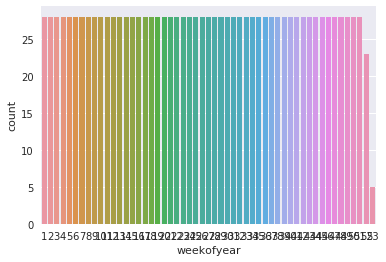

```python
# It appears no correction is necessary as the data is fairly continuous around 28 (although there is a minor drop off in the final weeks)
# To accomodate the minor drop off I'll combine week 53 with week 52
sns.countplot(train_df['weekofyear'])
```

```python
train_df['weekofyear'] = train_df['weekofyear'].replace(53, 52)
test_df['weekofyear'] = test_df['weekofyear'].replace(53, 52)
print(train_df['weekofyear'].value_counts())
```

```
52    28
51    28
24    28
23    28
22    28
21    28
20    28
19    28
18    28
17    28
16    28
15    28
14    28
13    28
12    28
```

[output cut: 38 more lines]

```python
train_df['weekofyear']=train_df['weekofyear']/52
test_df['weekofyear']=test_df['weekofyear']/52
```

```python
print(train_df['weekofyear'].sample(5))
```

```
332     0.730769
1181    0.211538
75      0.788462
759     0.942308
167     0.538462
Name: weekofyear, dtype: float64
```

# Now that we've fixed a few columns we can look at our main problem...

### NaN values !!

```python
print(train_df.isna().sum())
```

```
year                                       0
weekofyear                                 0
ndvi_ne                                  194
ndvi_nw                                   52
ndvi_se                                   22
ndvi_sw                                   22
precipitation_amt_mm                      13
reanalysis_air_temp_k                     10
reanalysis_avg_temp_k                     10
reanalysis_dew_point_temp_k               10
reanalysis_max_air_temp_k                 10
reanalysis_min_air_temp_k                 10
reanalysis_precip_amt_kg_per_m2           10
reanalysis_relative_humidity_percent      10
reanalysis_sat_precip_amt_mm              13
reanalysis_specific_humidity_g_per_kg     10
reanalysis_tdtr_k                         10
station_avg_temp_c                        43
station_diur_temp_rng_c                   43
station_max_temp_c                        20
station_min_temp_c                        14
station_precip_mm                         22
city_iq                                    0
city_sj                                    0
dtype: int64
```

The correlation coefficient has values between -1 to 1 - A value closer to 0 implies weaker correlation (exact 0 implying no correlation) - A value closer to 1 implies stronger positive correlation - A value closer to -1 implies stronger negative correlation

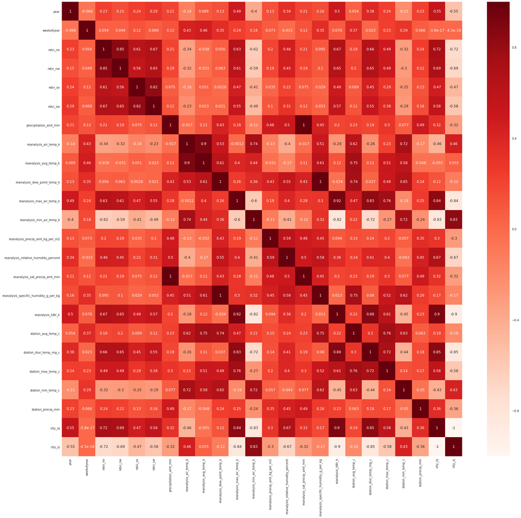

```python
#Using Pearson Correlation
plt.figure(figsize=(30,28))

sns.heatmap(train_df.corr(), annot=True, cmap=plt.cm.Reds)
plt.show()
```

## We can see right away that some of the features are essentially duplicates of each other and can be removed (i.e. reanalysis_sat_precip_amt_mm and precipitation_amt_mm)

#### We can also see that all of the ndvi features are related to each other. Let's use the correlatives to predict missing values

```python
lr_nw_to_ne = LinearRegression()
lr_nw_to_ne.fit(train_df.dropna()['ndvi_nw'].values.reshape(-1,1), train_df.dropna()['ndvi_ne'])

lr_sw_to_ne = LinearRegression()
lr_sw_to_ne.fit(train_df.dropna()['ndvi_sw'].values.reshape(-1,1), train_df.dropna()['ndvi_ne'])

lr_se_to_ne = LinearRegression()
lr_se_to_ne.fit(train_df.dropna()['ndvi_se'].values.reshape(-1,1), train_df.dropna()['ndvi_ne'])

print("NE       =  NW * {:.3f} + {:.3f}".format(lr_nw_to_ne.coef_[0], abs(lr_nw_to_ne.intercept_)))
print("NE       =  SW * {:.3f} - {:.3f}".format(lr_sw_to_ne.coef_[0], abs(lr_sw_to_ne.intercept_)))
print("NE       =  SE * {:.3f} - {:.3f}".format(lr_se_to_ne.coef_[0], abs(lr_se_to_ne.intercept_)))
```

```
NE       =  NW * 0.983 + 0.008
NE       =  SW * 1.084 - 0.083
NE       =  SE * 1.145 - 0.096
```

```python
lr_ne_to_nw = LinearRegression()
lr_ne_to_nw.fit(train_df.dropna()['ndvi_ne'].values.reshape(-1,1), train_df.dropna()['ndvi_nw'])

lr_sw_to_nw = LinearRegression()
lr_sw_to_nw.fit(train_df.dropna()['ndvi_sw'].values.reshape(-1,1), train_df.dropna()['ndvi_nw'])

lr_se_to_nw = LinearRegression()
lr_se_to_nw.fit(train_df.dropna()['ndvi_se'].values.reshape(-1,1), train_df.dropna()['ndvi_nw'])

print("NW       =  NE * {:.3f} + {:.3f}".format(lr_ne_to_nw.coef_[0], abs(lr_ne_to_nw.intercept_)))
print("NW       =  SW * {:.3f} - {:.3f}".format(lr_sw_to_nw.coef_[0], abs(lr_sw_to_nw.intercept_)))
print("NW       =  SE * {:.3f} - {:.3f}".format(lr_se_to_nw.coef_[0], abs(lr_se_to_nw.intercept_)))
```

```
NW       =  NE * 0.730 + 0.032
NW       =  SW * 0.933 - 0.058
NW       =  SE * 0.920 - 0.055
```

```python
lr_ne_to_se = LinearRegression()
lr_ne_to_se.fit(train_df.dropna()['ndvi_ne'].values.reshape(-1,1), train_df.dropna()['ndvi_se'])

lr_sw_to_se = LinearRegression()
lr_sw_to_se.fit(train_df.dropna()['ndvi_sw'].values.reshape(-1,1), train_df.dropna()['ndvi_se'])

lr_nw_to_se = LinearRegression()
lr_nw_to_se.fit(train_df.dropna()['ndvi_nw'].values.reshape(-1,1), train_df.dropna()['ndvi_se'])

print("SE       =  NE * {:.3f} + {:.3f}".format(lr_ne_to_se.coef_[0], abs(lr_ne_to_se.intercept_)))
print("SE       =  SW * {:.3f} - {:.3f}".format(lr_sw_to_se.coef_[0], abs(lr_sw_to_se.intercept_)))
print("SE       =  NW * {:.3f} - {:.3f}".format(lr_nw_to_se.coef_[0], abs(lr_nw_to_se.intercept_)))
```

```
SE       =  NE * 0.323 + 0.160
SE       =  SW * 0.715 - 0.059
SE       =  NW * 0.350 - 0.159
```

```python
lr_ne_to_sw = LinearRegression()
lr_ne_to_sw.fit(train_df.dropna()['ndvi_ne'].values.reshape(-1,1), train_df.dropna()['ndvi_sw'])

lr_se_to_sw = LinearRegression()
lr_se_to_sw.fit(train_df.dropna()['ndvi_se'].values.reshape(-1,1), train_df.dropna()['ndvi_sw'])

lr_nw_to_sw = LinearRegression()
lr_nw_to_sw.fit(train_df.dropna()['ndvi_nw'].values.reshape(-1,1), train_df.dropna()['ndvi_sw'])

print("SW       =  NE * {:.3f} + {:.3f}".format(lr_ne_to_sw.coef_[0], abs(lr_ne_to_sw.intercept_)))
print("SW       =  SE * {:.3f} - {:.3f}".format(lr_se_to_sw.coef_[0], abs(lr_se_to_sw.intercept_)))
print("SW       =  NW * {:.3f} - {:.3f}".format(lr_nw_to_sw.coef_[0], abs(lr_nw_to_sw.intercept_)))
```

```
SW       =  NE * 0.404 + 0.149
SW       =  SE * 0.943 - 0.012
SW       =  NW * 0.468 - 0.143
```

```python
def missing_value(missing_quad, index):

    # Initialize correlative predictor values
    correlative_pred_1 = 0
    correlative_pred_2 = 0
    correlative_pred_3 = 0
    count = 0

    if missing_quad == "ne":
        if not np.isnan(train_df['ndvi_se'][index]):
            correlative_pred_1 = train_df['ndvi_se'][index]*lr_se_to_ne.coef_[0]+lr_se_to_ne.intercept_
            count += 4
        if not np.isnan(train_df['ndvi_sw'][index]):
            correlative_pred_2 = train_df['ndvi_sw'][index]*lr_sw_to_ne.coef_[0]+lr_sw_to_ne.intercept_
            count += 4
        if not np.isnan(train_df['ndvi_nw'][index]):
            correlative_pred_3 = train_df['ndvi_nw'][index]*lr_nw_to_ne.coef_[0]+lr_nw_to_ne.intercept_
            count += 5

        if count is not 0:
            correlative_mean = sum([correlative_pred_1*4, correlative_pred_2*4, correlative_pred_3*5])/count
        else:
            correlative_mean = np.nan

    elif missing_quad == "nw":

        if not np.isnan(train_df['ndvi_se'][index]):
            correlative_pred_1 = train_df['ndvi_se'][index]*lr_se_to_nw.coef_[0]+lr_se_to_nw.intercept_
            count += 4
        if not np.isnan(train_df['ndvi_sw'][index]):
            correlative_pred_2 = train_df['ndvi_sw'][index]*lr_sw_to_nw.coef_[0]+lr_sw_to_nw.intercept_
            count += 4
        if not np.isnan(train_df['ndvi_ne'][index]):
            correlative_pred_3 = train_df['ndvi_ne'][index]*lr_ne_to_nw.coef_[0]+lr_ne_to_nw.intercept_
            count += 5

        if count is not 0:
            correlative_mean = sum([correlative_pred_1*4, correlative_pred_2*4, correlative_pred_3*5])/count
        else:
            correlative_mean = np.nan

    elif missing_quad == "se":

        if not np.isnan(train_df['ndvi_nw'][index]):
            correlative_pred_1 = train_df['ndvi_nw'][index]*lr_nw_to_se.coef_[0]+lr_nw_to_se.intercept_
            count += 4
        if not np.isnan(train_df['ndvi_sw'][index]):
            correlative_pred_2 = train_df['ndvi_sw'][index]*lr_sw_to_se.coef_[0]+lr_sw_to_se.intercept_
            count += 5
        if not np.isnan(train_df['ndvi_ne'][index]):
            correlative_pred_3 = train_df['ndvi_ne'][index]*lr_ne_to_se.coef_[0]+lr_ne_to_se.intercept_
            count += 4

        if count is not 0:
            correlative_mean = sum([correlative_pred_1*4, correlative_pred_2*5, correlative_pred_3*4])/count
        else:
            correlative_mean = np.nan
    else:

        if not np.isnan(train_df['ndvi_nw'][index]):
            correlative_pred_1 = train_df['ndvi_nw'][index]*lr_nw_to_sw.coef_[0]+lr_nw_to_sw.intercept_
            count += 4
        if not np.isnan(train_df['ndvi_se'][index]):
            correlative_pred_2 = train_df['ndvi_se'][index]*lr_se_to_sw.coef_[0]+lr_se_to_sw.intercept_
            count += 5
        if not np.isnan(train_df['ndvi_ne'][index]):
            correlative_pred_3 = train_df['ndvi_ne'][index]*lr_ne_to_sw.coef_[0]+lr_ne_to_sw.intercept_
            count += 4

        if count is not 0:
            correlative_mean = sum([correlative_pred_1*4, correlative_pred_2*5, correlative_pred_3*4])/count
        else:
            correlative_mean = np.nan

    return correlative_mean
```

```python
test_val = 17
print(train_df['ndvi_ne'][test_val], missing_value("ne", test_val))
```

```
0.2529 0.26084389219673365
```

```python
for idx in range(0, len(train_df['ndvi_ne'])):

    if np.isnan(train_df['ndvi_ne'][idx]):
        train_df['ndvi_ne'][idx] = missing_value("ne", idx)

    if np.isnan(train_df['ndvi_nw'][idx]):
        train_df['ndvi_nw'][idx] = missing_value("nw", idx)

    if np.isnan(train_df['ndvi_sw'][idx]):
        train_df['ndvi_sw'][idx] = missing_value("sw", idx)

    if np.isnan(train_df['ndvi_se'][idx]):
        train_df['ndvi_se'][idx] = missing_value("se", idx)

for idx in range(0, len(test_df['ndvi_ne'])):

    if np.isnan(test_df['ndvi_ne'][idx]):
        test_df['ndvi_ne'][idx] = missing_value("ne", idx)

    if np.isnan(test_df['ndvi_nw'][idx]):
        test_df['ndvi_nw'][idx] = missing_value("nw", idx)

    if np.isnan(test_df['ndvi_sw'][idx]):
        test_df['ndvi_sw'][idx] = missing_value("sw", idx)

    if np.isnan(test_df['ndvi_se'][idx]):
        test_df['ndvi_se'][idx] = missing_value("se", idx)
```

[output not shown]

## Now we go through and replace any further missing values with interpolated results of the values around them (for simplicity)

```python
train_df = train_df.interpolate(limit_direction='both')
test_df = test_df.interpolate(limit_direction='both')
```

```python
print(train_df.isna().sum())
```

```
year                                     0
weekofyear                               0
ndvi_ne                                  0
ndvi_nw                                  0
ndvi_se                                  0
ndvi_sw                                  0
precipitation_amt_mm                     0
reanalysis_air_temp_k                    0
reanalysis_avg_temp_k                    0
reanalysis_dew_point_temp_k              0
reanalysis_max_air_temp_k                0
reanalysis_min_air_temp_k                0
reanalysis_precip_amt_kg_per_m2          0
reanalysis_relative_humidity_percent     0
reanalysis_sat_precip_amt_mm             0
reanalysis_specific_humidity_g_per_kg    0
reanalysis_tdtr_k                        0
station_avg_temp_c                       0
station_diur_temp_rng_c                  0
station_max_temp_c                       0
station_min_temp_c                       0
station_precip_mm                        0
city_iq                                  0
city_sj                                  0
dtype: int64
```

# From the correlation matrix we can see that a few variables have a correlation of 1... we can remove them

```python
train_df = train_df.drop(['reanalysis_sat_precip_amt_mm', 'reanalysis_specific_humidity_g_per_kg', 'city_iq'], axis=1)
test_df = test_df.drop(['reanalysis_sat_precip_amt_mm', 'reanalysis_specific_humidity_g_per_kg', 'city_iq'], axis=1)
```

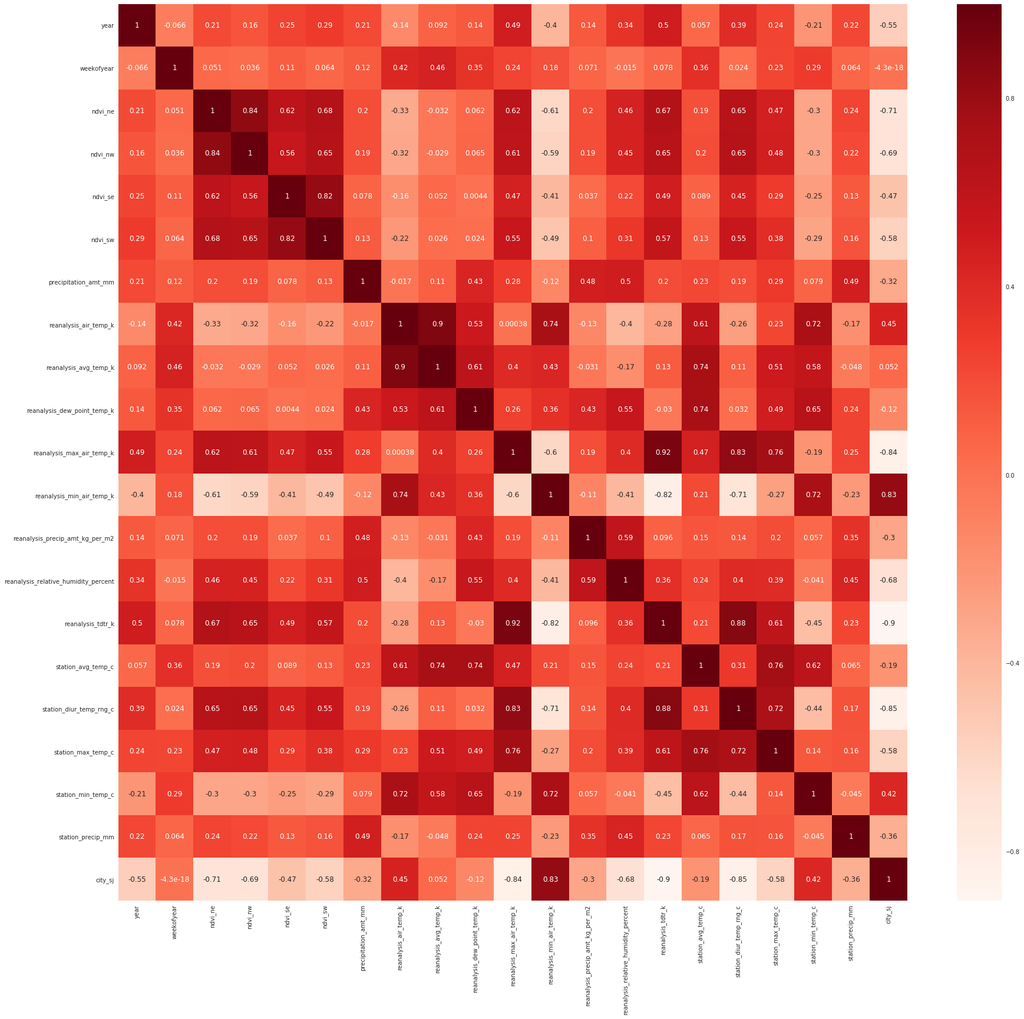

```python
#Using Pearson Correlation
plt.figure(figsize=(30,28))

sns.heatmap(train_df.corr(), annot=True, cmap=plt.cm.Reds)
plt.show()
```

# Time to perform mean normalization on every column

$$x^{'} = \frac{x - average(x)}{max(x)-min(x)}$$

- **where x is an original value**
- **where x' is the normalized value**

```python
# Define mean normalization function
def mean_norm_col(df_col):
    col_min = min(df_col)
    col_max = max(df_col)
    col_ave = sum(df_col)/len(df_col)

    col_norm = (df_col - col_ave)/(col_max-col_min)
    return col_norm
```

```python
for col in ['precipitation_amt_mm', 'reanalysis_air_temp_k', 'reanalysis_avg_temp_k', 'reanalysis_dew_point_temp_k',
            'reanalysis_max_air_temp_k', 'reanalysis_min_air_temp_k', 'reanalysis_precip_amt_kg_per_m2',
            'reanalysis_relative_humidity_percent', 'reanalysis_tdtr_k', 'station_avg_temp_c',
            'station_diur_temp_rng_c', 'station_max_temp_c', 'station_min_temp_c', 'station_precip_mm']:
    train_df[col] = mean_norm_col(train_df[col])
    test_df[col] = mean_norm_col(test_df[col])
```

```python
print(train_df.sample(5))
```

```
      year  weekofyear   ndvi_ne   ndvi_nw   ndvi_se   ndvi_sw  \
1326   0.9    0.019231  0.191471  0.155414  0.176014  0.187243
1118   0.7    0.019231  0.202571  0.198967  0.244557  0.187957
1328   0.9    0.057692  0.188229  0.220829  0.233243  0.169971
1042   0.6    0.557692  0.108043  0.072986  0.111229  0.117971
261    0.2    0.346154  0.133668  0.152100  0.214543  0.157971

      precipitation_amt_mm  reanalysis_air_temp_k  reanalysis_avg_temp_k  \
1326             -0.065930               0.076596               0.163519
1118              0.046782              -0.242007              -0.164926
1328              0.128694              -0.087710               0.031963
1042              0.044285              -0.298097              -0.184037
261              -0.063344               0.012007              -0.018703

      reanalysis_dew_point_temp_k   ...     reanalysis_min_air_temp_k  \
```

[output cut: 28 more lines]

## Since the log function which will correct skew is not defined for negative values we will shift all the values by slightly more than the most negative number found in the sets (-0.68)

```python
for col in ['precipitation_amt_mm', 'reanalysis_air_temp_k', 'reanalysis_avg_temp_k', 'reanalysis_dew_point_temp_k',
            'reanalysis_max_air_temp_k', 'reanalysis_min_air_temp_k', 'reanalysis_precip_amt_kg_per_m2',
            'reanalysis_relative_humidity_percent', 'reanalysis_tdtr_k', 'station_avg_temp_c',
            'station_diur_temp_rng_c', 'station_max_temp_c', 'station_min_temp_c', 'station_precip_mm', 'ndvi_ne',
            'ndvi_nw','ndvi_se','ndvi_sw']:
    train_df[col] = train_df[col]+abs(min(train_df[col]))+0.01
    test_df[col] = test_df[col]+abs(min(test_df[col]))+0.01
```

## So, when is the skewness too much?

#### The rule of thumb seems to be:

- If the skewness is between **-0.5 and 0.5**, the data is fairly symmetrical.
- If the skewness is between **-1 and -0.5(negatively skewed) or between 0.5 and 1(positively skewed)**, the data is moderately skewed.
- If the skewness is less than **-1(negatively skewed) or greater than 1(positively skewed)**, the data is highly skewed.

# Kurtosis

### Kurtosis is all about the tails of the distribution — not the peakedness or flatness.

### It is used to describe the extreme values in one versus the other tail.

## It is actually the measure of **outliers** present in the distribution.

High kurtosis in a data set is an indicator that data has heavy tails or outliers. If there is a high kurtosis, then, we need to investigate why do we have so many outliers. It indicates a lot of things, maybe wrong data entry or other things. Investigate! Low kurtosis in a data set is an indicator that data has light tails or lack of outliers. If we get low kurtosis(too good to be true), then also we need to investigate and trim the dataset of unwanted results.

- Mesokurtic: This distribution has kurtosis statistic similar to that of the normal distribution. It means that the extreme values of the distribution are similar to that of a normal distribution characteristic.
  - This definition is used so that the standard normal distribution has a kurtosis of **3**.
- Leptokurtic (**Kurtosis > 3**): Distribution is longer, tails are fatter. Peak is higher and sharper than Mesokurtic, which means that data are heavy-tailed or profusion of outliers.
  - Outliers stretch the horizontal axis of the histogram graph, which makes the bulk of the data appear in a narrow (“skinny”) vertical range, thereby giving the “skinniness” of a leptokurtic distribution.
- Platykurtic: (**Kurtosis < 3**): Distribution is shorter, tails are thinner than the normal distribution. The peak is lower and broader than Mesokurtic, which means that data are light-tailed or lack of outliers. The reason for this is because the extreme values are less than that of the normal distribution.

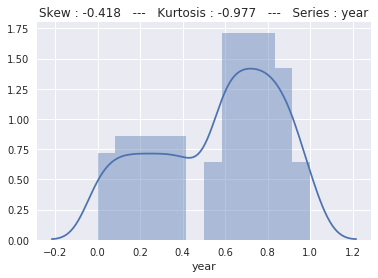

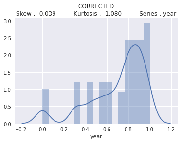

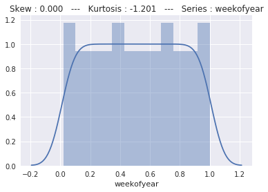

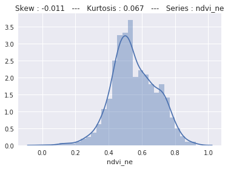

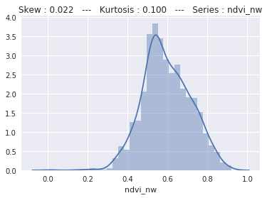

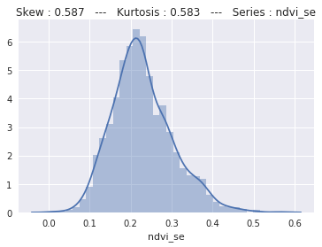

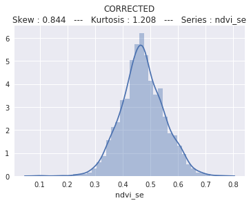

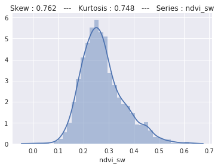

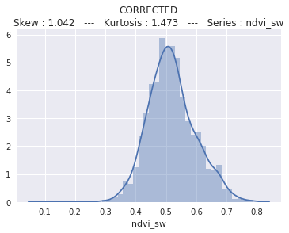

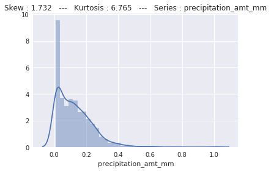

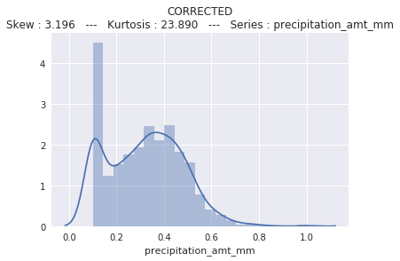

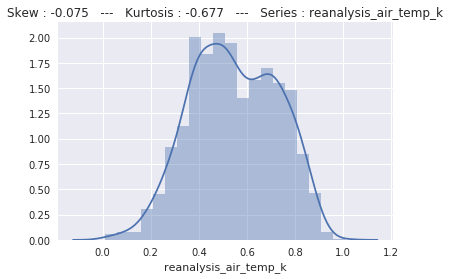

[25 more figures not shown]

```python
for col in train_df.columns:
    sns.distplot(train_df[col]).set_title("Skew : {:.3f}   ---   Kurtosis : {:.3f}   ---   Series : {}".format(train_df[col].skew(), train_df[col].kurt(),col))
    plt.show()

    if abs(train_df[col].skew()) > 0.25:
        sns.distplot(np.sqrt(train_df[col])).set_title("CORRECTED\nSkew : {:.3f}   ---   Kurtosis : {:.3f}   ---   Series : {}".format(np.exp(train_df[col]).skew(), np.exp(train_df[col]).kurt(),col))
        plt.show()
```

```python
to_be_log = ['reanalysis_max_air_temp_k', 'reanalysis_precip_amt_kg_per_m2',
                'reanalysis_tdtr_k', 'station_precip_mm']
to_be_sqrt = ['ndvi_se', 'ndvi_sw', 'reanalysis_relative_humidity_percent', 'station_diur_temp_rng_c', 'precipitation_amt_mm']
```

```python
for col in train_df.columns:
    if col in to_be_log:
        train_df[col] = np.log(train_df[col])
        test_df[col] = np.log(test_df[col])
    elif col in to_be_sqrt:
        train_df[col] = np.sqrt(train_df[col])
        test_df[col] = np.sqrt(test_df[col])
    else:
        pass
```

```python
for col in train_df.columns:
    print("Skew : {:.3f}   ---   Kurtosis : {:.3f}   ---   Series : {}".format(train_df[col].skew(), train_df[col].kurt(),col))
```

```
Skew : -0.418   ---   Kurtosis : -0.977   ---   Series : year
Skew : 0.000   ---   Kurtosis : -1.201   ---   Series : weekofyear
Skew : -0.011   ---   Kurtosis : 0.067   ---   Series : ndvi_ne
Skew : 0.022   ---   Kurtosis : 0.100   ---   Series : ndvi_nw
Skew : 0.016   ---   Kurtosis : 0.467   ---   Series : ndvi_se
Skew : 0.230   ---   Kurtosis : 0.658   ---   Series : ndvi_sw
Skew : 0.285   ---   Kurtosis : -0.254   ---   Series : precipitation_amt_mm
Skew : -0.075   ---   Kurtosis : -0.677   ---   Series : reanalysis_air_temp_k
Skew : -0.185   ---   Kurtosis : -0.531   ---   Series : reanalysis_avg_temp_k
Skew : -0.718   ---   Kurtosis : -0.114   ---   Series : reanalysis_dew_point_temp_k
Skew : -0.333   ---   Kurtosis : 0.430   ---   Series : reanalysis_max_air_temp_k
Skew : -0.673   ---   Kurtosis : -0.201   ---   Series : reanalysis_min_air_temp_k
Skew : 0.096   ---   Kurtosis : -0.305   ---   Series : reanalysis_precip_amt_kg_per_m2
Skew : 0.131   ---   Kurtosis : 0.554   ---   Series : reanalysis_relative_humidity_percent
Skew : 0.352   ---   Kurtosis : -1.206   ---   Series : reanalysis_tdtr_k
Skew : -0.562   ---   Kurtosis : -0.125   ---   Series : station_avg_temp_c
Skew : 0.286   ---   Kurtosis : -0.556   ---   Series : station_diur_temp_rng_c
Skew : -0.259   ---   Kurtosis : 0.203   ---   Series : station_max_temp_c
Skew : -0.304   ---   Kurtosis : 0.228   ---   Series : station_min_temp_c
Skew : 0.092   ---   Kurtosis : -0.664   ---   Series : station_precip_mm
Skew : -0.597   ---   Kurtosis : -1.646   ---   Series : city_sj
```